# Question

You should feel pretty comfortable with the following:

$$7^2\cdot 7^3 ~=~ 7^5$$

$$(7^2)^3~=~7^6$$

The governing rules can be written as $x^ax^b\equiv x^{a+b}$ and $(x^a)^b\equiv x^{ab}$.

The square root “undoes” squaring of positive numbers.

$$\sqrt{7^2}~=~7$$

But, notice, it fails for negative numbers.

$$\sqrt{(-7)^2} ~\ne~ -7$$

If we ignore that problem for a moment, we could recognize “another” way to undo squaring, based on the rule $(x^a)^b=x^{ab}$:

$$(7^2)^{1/2} ~=~ 7^{2\cdot \frac{1}{2}}
~=~ 7^1 ~=~ 7$$

But, actually, we’ve just stumbled upon a useful identity: raising to the 1/2 power is equivalent to taking a square root.

$$\sqrt{x} ~\equiv~ x^{1/2}$$

For example, $\sqrt{10}\approx3.1622777$ and also $10^{0.5}\approx3.1622777$.

To undo cubing, you can take a cube root. Raising to the 1/3 is equivalent to a cube root.

$$\sqrt[3]{5^3}~=~(5^3)^{1/3}~=~5^1~=~5$$

Notice, if we plot $y=x^3$ and $y=\sqrt[3]{x}$, we see the two curves have reflective symmetry over the $y=x$ line.

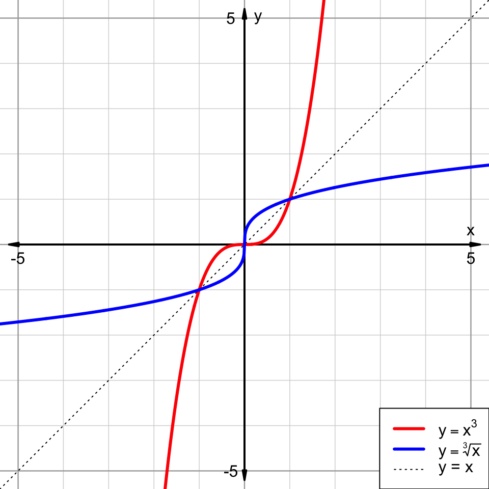

Inverse functions! So, if $f(x)=x^3$ then $f^{-1}(x)=\sqrt[3]{x}$.

Now, let’s get back to squaring and square rooting. If we graph $y=x^2$ and $y=\sqrt{x}$, we see something like inverse functions. Unfortunately, $y=x^2$ is **NOT A ONE-TO-ONE FUNCTION**, and so it is impossible to perfectly undo. To move forward, we restrict the domain over which $y=x^2$ is one-to-one for building our best attempt at an inverse.

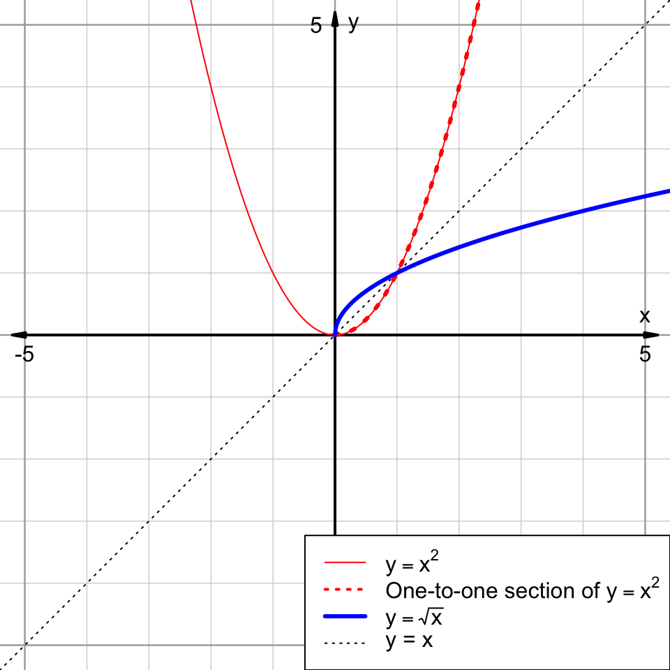

# Meta-information